# TEXT MINING HOMEWORK

## 02 Text encoding

```python
def clean_text(docs, logging, stopwords, punctuations):
    texts = []
    for i, doc in enumerate(docs):
        if (i+1) % 2000 == 0 and logging:
            print("Processed %d out of %d documents." % (i+1, len(docs)))
    doc = nlp(doc, disable=['parser', 'ner'])
    tokens = [tok.lemma_.lower().strip() for tok in doc if tok.lemma_ != '-PRON-']
    tokens = [tok for tok in tokens if tok not in stopwords and tok not in punctuations]
    tokens = ' '.join(tokens)
    texts.append(tokens)
    return texts
```

```python
text_trn = clean_text(text_train, logging=True, stopwords = stopwords, punctuations=string.punctuation)
```

```
Processed 2000 out of 9051 documents.
Processed 4000 out of 9051 documents.
Processed 6000 out of 9051 documents.
Processed 8000 out of 9051 documents.
```

```python
len(text_trn)
```

[output not shown]

```python
np.mean(pd.Series(text_trn).apply(lambda x: len(x)))
```

```
1273.296320848525
```

```python
np.std(pd.Series(text_trn).apply(lambda x: len(x)))
```

```
2957.9852641302305
```

```python
text_val = clean_text(text_valid, logging=True, stopwords = stopwords, punctuations=string.punctuation)
```

```
Processed 2000 out of 2263 documents.
```

```python
# ------------------------------------
# Define your own encoding proccess here
# ------------------------------------

# EXAMPLE OF CODE

# Extract word ocurrences
tf_vectorizer = CountVectorizer(max_df=0.95, min_df=2,
                                max_features=20000,
                                stop_words='english')
X_train_counts = tf_vectorizer.fit_transform(text_trn)

#From occurrences to frequencies
tfidf_transformer = TfidfTransformer().fit(X_train_counts)

def encoding_text(text):
    '''
    Encoding function
        Input: raw text
        Output: features to train the model
    '''
    text_counts = tf_vectorizer.transform(text)
    text_tf = tfidf_transformer.transform(text_counts)
    return text_tf

# Encode train
X_trn = encoding_text(text_trn)
print(X_trn.shape)

X_vl = encoding_text(text_val)
```

```
(9051, 20000)
```

```python
def encoding_text(text):
    '''
    Encoding function
        Input: raw text
        Output: features to train the model
    '''
    text_counts = tf_vectorizer.transform(text)
    text_tf = tfidf_transformer.transform(text_counts)
    return text_tf
```

## BASELINE MODEL

```python
# ------------------------------------
# Put your model or models here
# ------------------------------------

# EXAMPLE OF CODE
# Define and fit in one line
clf = MultinomialNB().fit(X_trn, y_train)
# END OF EXAMPLE OF CODE


clf.score(X_vl, y_val)
```

```
0.891736632788334
```

## DATA PREPARATION FOR DEEP LEARNING

```python
punctuations=string.punctuation
```

```python
tokenizer = Tokenizer(num_words = 20000)
tokenizer.fit_on_texts(text_trn)
```

```python
embeddings = load_vectors_words('./glove/glove.6B.100d.txt', tokenizer.word_index)
```

```python
embeddings['religion']
```

```
array([ 3.8767e-01,  5.2666e-01,  3.2148e-01, -5.9078e-02,  1.4548e-02,
        1.2165e+00, -2.8820e-01, -9.8393e-01,  5.7100e-01,  5.0296e-01,
       -8.5728e-01, -1.2365e-02,  5.2527e-01,  6.3542e-01, -8.6523e-02,
       -6.4220e-01,  5.1568e-01,  1.7071e-01, -1.4124e+00,  4.1574e-01,
        7.7298e-02, -4.7173e-01,  1.6752e-01,  1.0464e-01,  2.8658e-01,
       -2.4441e-01,  4.0884e-01, -5.9442e-01, -2.0989e-01,  1.1836e-01,
       -4.5125e-01,  6.3722e-01, -4.7512e-01, -1.0123e-01, -4.2927e-01,
       -8.4314e-02, -5.7143e-02,  6.4248e-01, -5.3217e-01, -3.0255e-02,
       -1.6149e+00,  1.6909e-01,  5.0364e-02, -1.2316e-01, -1.1662e+00,
       -1.4332e+00,  4.0662e-01,  7.1394e-01, -5.3511e-01, -9.4195e-01,
        6.3921e-01,  8.5204e-01,  1.1757e-01,  2.7940e-01, -3.7898e-01,
       -1.4049e+00,  6.4129e-01,  7.7752e-02,  1.4301e+00,  3.6431e-02,
        6.0694e-02, -1.1164e-03,  2.2120e-01, -1.1701e+00,  8.7979e-01,
        2.7767e-01,  5.8127e-01, -6.0318e-01,  4.8540e-01,  3.7614e-01,
       -1.2393e-01,  1.5302e-01,  4.8930e-01,  5.4346e-01, -3.9262e-01,
       -2.6720e-01, -7.0061e-01, -3.7829e-01, -7.9800e-01, -2.4582e-01,
       -8.5558e-01, -4.1035e-02, -2.1130e-01,  1.8789e-01, -5.3728e-01,
        4.7110e-01, -7.3287e-01, -4.6197e-01,  4.6724e-01, -3.4757e-01,
       -2.8272e-01, -6.4220e-01,  4.3477e-01,  2.8996e-01, -4.3642e-01,
       -6.9240e-01, -5.1757e-01, -1.0258e+00,  5.8707e-01,  6.6182e-01])
```

```python
embedding_matrix = create_embedding_matrix(embeddings, tokenizer)
```

```python
embedding_matrix.shape
```

```
(20000, 100)
```

```python
text_trn[0]
```

```
"ptrei@bistromath.mitre.org peter trei subject fifth amendment passwords nntp posting host bistromath.mitre.org organization mitre corporation lines 33 article 1993apr17.122651.1874@sugra.uucp ken@sugra.uucp kenneth ng write article 1993apr16.165423.27204@linus.mitre.org ptrei@bistromath.mitre.org p…
```

```python
text_train[0]
```

```
'From: ptrei@bistromath.mitre.org (Peter Trei)\nSubject: Re: Fifth Amendment and Passwords\nNntp-Posting-Host: bistromath.mitre.org\nOrganization: The MITRE Corporation\nLines: 33\n\nIn article <1993Apr17.122651.1874@sugra.uucp> ken@sugra.uucp (Kenneth Ng) writes:\n>In article <1993Apr16.165423.2720…
```

```python
def tokenizar(texts, nwords=20000, mode='sequence', seqlen = None):

    tokenizer = Tokenizer(num_words=nwords)
    tokenizer.fit_on_texts(text_trn)

    if mode == 'sequence':

        X = tf.keras.preprocessing.sequence.pad_sequences(tokenizer.texts_to_sequences(texts), maxlen=seqlen)

    elif mode == 'matrix':

        X = tokenizer.texts_to_matrix(texts, mode='tfidf')

    return X
```

```python
Xtrain = tokenizar(text_train, nwords=20000, seqlen=1000, mode='sequence')
Xval = tokenizar(text_valid, nwords=20000, seqlen=1000, mode='sequence')
```

```python
encoder = LabelBinarizer()

encoder.fit(y_train)

y_trn, y_val = encoder.transform(y_train), encoder.transform(y_val)
```

```python
y_trn.shape
```

```
(9051, 20)
```

## 03 Models and score function

## Modelos de Deep Learning

Aunque para esta parte se han probado muchísimos modelos diferentes, de todos los colores y formas, se dejan en el notebook aquellos necesarios para tener una idea aproximada de en qué líneas se han hecho las pruebas. Como se comentó en la introducción, algunos están escritos con tf.keras y otros con keras, por los motivos que se indicaron en la introducción.

### Modelos 1: LSTM + Pretrained Embedding from Glove

Este modelo de abajo no lo pondremos a entrenar; ya se entrenó en su momento y los resultados eran muy malos. Está aquí más que nada para que se vea cómo sería la implementación de un LSTM con tensorflow; sin embargo, como ya dije en la introducción, tf.keras no permite actualmente el uso de CuDNNLSTM, y por lo tanto tarda una eternidad en cada época.

```python
def build_lstm(lstm_u1, lstm_u2, maxwords, maxseq, emb_out, dropout, emb_mat):

    inp = tf.keras.layers.Input(shape=(maxseq, ), dtype='int32')

    embed = tf.keras.layers.Embedding(maxwords, emb_out, weights=[embedding_matrix])(inp)

    drop = tf.keras.layers.SpatialDropout1D(dropout)(embed)

    lstm1 = tf.keras.layers.LSTM(lstm_u1, return_sequences=True, name='Forward')(drop)

    lstm2 = tf.keras.layers.LSTM(lstm_u2, return_sequences=False, name='Forward2')(lstm1)

    output = tf.keras.layers.Dense(20, name="output", activation='softmax')(lstm2)

    model = tf.keras.models.Model(inputs=inp, outputs=output)

    model.compile(optimizer='adam', loss={'output':'categorical_crossentropy'}, metrics={'output':'categorical_accuracy'})

    return model
```

```python
class LossHistory(keras.callbacks.Callback):
    def on_train_begin(self, logs={}):
        self.losses = []
        self.accuracies = []

    def on_batch_end(self, batch, logs={}):
        self.losses.append(logs.get('loss'))
        self.accuracies.append(logs.get('accuracy'))

rlr = ReduceLROnPlateau(patience=1,  factor=0.2, verbose=1)
es = EarlyStopping(monitor='val_loss', patience=5, min_delta=0.01, verbose=1)

lh = LossHistory()
```

Creamos una clase LossHistory que hereda de la clase Callback; esta nueva clase que hemos creado sobreescribe los métodos on_train_begin y on_batch_end para darnos los valores de pérdida y de accuracy en cada momento de entrenamiento, de tal forma que luego podemos dibujarlos.

## Modelos Convolucionales (+ Embedding de Glove)

```python
def convModel(embedding_dim, maxseq):

    sequence_input = Input(shape=(maxseq,), dtype='int32')
    embedd = Embedding(20000,
                            embedding_matrix.shape[1],
                            weights=[embedding_matrix],
                            input_length=maxseq,
                            trainable=True)(sequence_input)
    spdr = SpatialDropout1D(0.2)(embedd)
    x = Conv1D(128, 5, activation='relu')(spdr)
    x = MaxPooling1D(5)(x)
    spdr2 = SpatialDropout1D(0.2)(x)
    x = Conv1D(128, 5, activation='relu')(spdr2)
    x = MaxPooling1D(5)(x)
    spdr3 = SpatialDropout1D(0.2)(x)
    x = Conv1D(128, 5, activation='relu')(spdr3)
    x = MaxPooling1D(35)(x)  # global max pooling
    x = Flatten()(x)
    x = Dense(128, activation='relu')(x)
    dr = Dropout(0.2)(x)
    preds = Dense(20, activation='softmax')(dr)

    model = Model(sequence_input, preds)
    model.compile(loss='categorical_crossentropy',
                optimizer='rmsprop',
                metrics=['acc'])

    return model
```

```python
conv_model = convModel(100, 1000)
```

[output not shown]

```python
tbCallBack = tf.keras.callbacks.TensorBoard(log_dir='./tensorboard/news/ConvModel_Preprocessed')
```

```python
conv_model.fit(Xtrain, y_trn,epochs=100, verbose=1, callbacks=[lh, rlr, es, tbCallBack], validation_data=(Xval, y_val), batch_size=128)
```

```
WARNING:tensorflow:From /usr/local/lib/python3.6/dist-packages/tensorflow/python/ops/math_ops.py:3066: to_int32 (from tensorflow.python.ops.math_ops) is deprecated and will be removed in a future version.
Instructions for updating:
Use tf.cast instead.
Train on 9051 samples, validate on 2263 samples

Epoch 00017: ReduceLROnPlateau reducing learning rate to 0.00020000000949949026.

Epoch 00019: ReduceLROnPlateau reducing learning rate to 4.0000001899898055e-05.

Epoch 00020: ReduceLROnPlateau reducing learning rate to 8.000000525498762e-06.

Epoch 00021: ReduceLROnPlateau reducing learning rate to 1.6000001778593287e-06.

Epoch 00022: ReduceLROnPlateau reducing learning rate to 3.200000264769187e-07.

Epoch 00023: ReduceLROnPlateau reducing learning rate to 6.400000529538374e-08.
Epoch 00023: early stopping
```

```
<keras.callbacks.History at 0x7f94774dccc0>
```

```python
%tensorboard --logdir ./tensorboard/news --host=127.0.0.1
```

```
Reusing TensorBoard on port 6006 (pid 854), started 6:17:35 ago. (Use '!kill 854' to kill it.)
```

Algunas apreciaciones que se ven el Tensorboard es que al haber puesto el Embedding entrenable pasamos de un accuracy en validación de 0.79 a 0.85, lo cual está muy bien, aunque sigue sin ser del todo satisfactorio.

## Mezclas de Capas Densas y LSTMs (también Bidireccionales).

Aunque, como dijimos antes, hemos probado muchísimos modelos, ponemos sólo un ejemplo de los que hemos probado. Funcionaban todos muy mal, haciendo mucho overfitting. Especialmente cuando le introducimos la bidireccionalidad a las LSTMs nos cargamos su funcionamiento. Sin esto aún tienen unos errores más o menos decentes (aunque tirando a malos) pero en el momento en que utilizamos bidireccionales se nos estropea el rendimiento del todo.

```python
def build_model(lstm_u, maxseq, maxwords, embedding_matrix, dropout, rec_drop=None):


    inp = Input(shape=(maxseq, ), dtype='int32')

    embed = Embedding(maxwords, embedding_matrix.shape[1], weights=[embedding_matrix], trainable=True)(inp)

    drop = SpatialDropout1D(dropout)(embed)

    lstm = Bidirectional(CuDNNLSTM(lstm_u, return_sequences=True))(drop)

    #drop2 = SpatialDropout1D(dropout/2)(lstm)

    #lstm2 = Bidirectional(CuDNNGRU(int(lstm_u/2), return_sequences = True)) (drop2)

    avg_pool = GlobalAveragePooling1D()(lstm)
    #max_pool = GlobalMaxPool1D()(att)
    #conc = concatenate([avg_pool, max_pool])

    drop2 = Dropout(0.3) (avg_pool)

    de = Dense(200, activation='relu') (drop2)

    dr = Dropout(dropout)(de)

    outp = Dense(20, activation='softmax')(dr)

    model = Model(inputs=inp, outputs=outp)

    model.compile(loss='categorical_crossentropy', optimizer='adam', metrics=['accuracy'])

    return model
```

```python
embedding_matrix.shape
```

```
(20000, 100)
```

```python
tbCallBack2 = tf.keras.callbacks.TensorBoard(log_dir='./tensorboard/news/BiLSTM')
```

```python
mymodel = build_model(lstm_u=10, maxwords=20000, maxseq=1000, embedding_matrix=embedding_matrix, dropout=0.3)

mymodel.summary()

mymodel.fit(Xtrain, y_trn, batch_size=16, epochs=100, verbose=1, validation_data=(Xval, y_val), callbacks=[es, rlr, lh, tbCallBack2])
```

```
_________________________________________________________________
Layer (type)                 Output Shape              Param #
=================================================================
input_2 (InputLayer)         (None, 1000)              0
_________________________________________________________________
embedding_2 (Embedding)      (None, 1000, 100)         2000000
_________________________________________________________________
spatial_dropout1d_4 (Spatial (None, 1000, 100)         0
_________________________________________________________________
bidirectional_1 (Bidirection (None, 1000, 20)          8960
_________________________________________________________________
global_average_pooling1d_1 ( (None, 20)                0
_________________________________________________________________
dropout_2 (Dropout)          (None, 20)                0
_________________________________________________________________
dense_3 (Dense)              (None, 200)               4200
_________________________________________________________________
dropout_3 (Dropout)          (None, 200)               0
_________________________________________________________________
dense_4 (Dense)              (None, 20)                4020
=================================================================
Total params: 2,017,180
Trainable params: 2,017,180
Non-trainable params: 0
_________________________________________________________________
Train on 9051 samples, validate on 2263 samples

Epoch 00016: ReduceLROnPlateau reducing learning rate to 0.00020000000949949026.

Epoch 00018: ReduceLROnPlateau reducing learning rate to 4.0000001899898055e-05.

Epoch 00023: ReduceLROnPlateau reducing learning rate to 8.000000525498762e-06.

Epoch 00024: ReduceLROnPlateau reducing learning rate to 1.6000001778593287e-06.

Epoch 00025: ReduceLROnPlateau reducing learning rate to 3.200000264769187e-07.

Epoch 00026: ReduceLROnPlateau reducing learning rate to 6.400000529538374e-08.

Epoch 00027: ReduceLROnPlateau reducing learning rate to 1.2800001059076749e-08.
Epoch 00027: early stopping
```

```
<keras.callbacks.History at 0x7f936b44c668>
```

```python
%tensorboard --logdir ./tensorboard/news --host=127.0.0.1
```

```
Reusing TensorBoard on port 6006 (pid 854), started 6:36:23 ago. (Use '!kill 854' to kill it.)
```

## Modelos de Convolucionales + RNNs + Self-Attention + Embedding Pre-entrenado de Glove

```python
def build_model_seq(n_conv, lstmU, ksize, pool_size, pad, maxseq, maxwords, embedding_matrix, rec_drop=None):

  from keras_self_attention import SeqSelfAttention

  model = Sequential()

  model.add(Embedding(maxwords, embedding_matrix.shape[1], input_length=maxseq, weights=[embedding_matrix], trainable=True))

  #model.add(Dropout(0.3))
  model.add(SpatialDropout1D(0.3))

  model.add(Conv1D(n_conv, ksize, activation='relu', padding='causal'))
  model.add(Conv1D(n_conv, ksize, activation='relu', padding='causal'))
  model.add(Conv1D(n_conv, ksize, activation='relu', padding='causal'))

  model.add(MaxPool1D(pool_size, padding=pad))

  model.add(Dropout(0.3))

  '''
  model.add(Conv1D(512, 3, activation='relu'))
  model.add(Conv1D(512, 3, activation='relu'))
  model.add(MaxPool1D())

  model.add(Dropout(0.2))
  '''
  model.add(CuDNNGRU(lstmU, return_sequences=True, recurrent_regularizer=keras.regularizers.l2(1e-5),
                     kernel_regularizer=keras.regularizers.l2(1e-5), bias_regularizer=keras.regularizers.l2(1e-5)))

  #model.add(SpatialDropout1D(0.2))
  #model.add(CuDNNLSTM(128, return_sequences=True))


  model.add(SeqSelfAttention(trainable=True, attention_type=SeqSelfAttention.ATTENTION_TYPE_MUL,
                       kernel_regularizer=keras.regularizers.l2(1e-5),
                       bias_regularizer=keras.regularizers.l1(1e-5),
                       attention_regularizer_weight=1e-5))



  '''
  model.add(SeqSelfAttention(trainable=True, attention_type=SeqSelfAttention.ATTENTION_TYPE_MUL,
                            kernel_regularizer=keras.regularizers.l2(1e-3),
                            bias_regularizer=keras.regularizers.l1(1e-4),
                            attention_regularizer_weight=1e-3))


  '''
  model.add(GlobalMaxPool1D())
  #model.add(MaxPooling1D(35))
  #model.add(Dense(200, activation='relu'))
  #model.add(Flatten())
  model.add(Dropout(0.3))

  #model.add(Dense(200, activation='relu'))

  #model.add(Dropout(0.4))

  model.add(Dense(20, activation='softmax'))

  model.compile(loss='categorical_crossentropy', optimizer='rmsprop', metrics=['accuracy'])

  return model
```

```python
rlr = ReduceLROnPlateau(patience=1,  factor=0.2, verbose=1)
es = EarlyStopping(monitor='val_loss', patience=5, min_delta=0.01, verbose=1)

lh = LossHistory()

tbCallBack3 = tf.keras.callbacks.TensorBoard(log_dir='./tensorboard/news/SeqModelGRU_Preprocessed')

modelseq = build_model_seq(128, 256, 5, 5, 'same',1000, 20000, embedding_matrix=embedding_matrix)

historySeq = modelseq.fit(Xtrain, y_trn, epochs=500, validation_data=(Xval, y_val), callbacks=[rlr, es, lh, tbCallBack3])
```

```
WARNING:tensorflow:From /usr/local/lib/python3.6/dist-packages/tensorflow/python/ops/math_grad.py:102: div (from tensorflow.python.ops.math_ops) is deprecated and will be removed in a future version.
Instructions for updating:
Deprecated in favor of operator or tf.math.divide.
Train on 9051 samples, validate on 2263 samples

Epoch 00012: ReduceLROnPlateau reducing learning rate to 0.00020000000949949026.

Epoch 00014: ReduceLROnPlateau reducing learning rate to 4.0000001899898055e-05.

Epoch 00015: ReduceLROnPlateau reducing learning rate to 8.000000525498762e-06.

Epoch 00016: ReduceLROnPlateau reducing learning rate to 1.6000001778593287e-06.

Epoch 00017: ReduceLROnPlateau reducing learning rate to 3.200000264769187e-07.

Epoch 00018: ReduceLROnPlateau reducing learning rate to 6.400000529538374e-08.
Epoch 00018: early stopping
```

```python
%tensorboard --logdir ./tensorboard/news --host=127.0.0.1
```

```
Reusing TensorBoard on port 6006 (pid 854), started 6:39:53 ago. (Use '!kill 854' to kill it.)
```

Gracias a TensorBoard podemos comparar el resultado de las distintas redes neuronales que hemos estado utilizando.

## MLPs.

```python
def model():

  model = Sequential()
  model.add(Dense(400, input_shape=(20000,)))
  model.add(Activation('relu'))
  model.add(Dropout(0.6))
  model.add(Dense(400))
  model.add(Activation('relu'))
  model.add(Dropout(0.6))
  model.add(Dense(20))
  model.add(Activation('softmax'))
  model.summary()

  model.compile(loss='categorical_crossentropy',
                optimizer='adam',
                metrics=['accuracy'])

  return model

model = model()

tbCallBack4 = tf.keras.callbacks.TensorBoard(log_dir='./tensorboard/news/mlp')


history = model.fit(X_trn, y_trn,
                    batch_size=100,
                    epochs=30,
                    verbose=1,
                    validation_data=(X_vl, y_val),
                   callbacks=[lh, es, rlr, tbCallBack4])
```

```
_________________________________________________________________
Layer (type)                 Output Shape              Param #
=================================================================
dense_6 (Dense)              (None, 400)               8000400
_________________________________________________________________
activation_1 (Activation)    (None, 400)               0
_________________________________________________________________
dropout_6 (Dropout)          (None, 400)               0
_________________________________________________________________
dense_7 (Dense)              (None, 400)               160400
_________________________________________________________________
activation_2 (Activation)    (None, 400)               0
_________________________________________________________________
dropout_7 (Dropout)          (None, 400)               0
_________________________________________________________________
dense_8 (Dense)              (None, 20)                8020
_________________________________________________________________
activation_3 (Activation)    (None, 20)                0
=================================================================
Total params: 8,168,820
Trainable params: 8,168,820
Non-trainable params: 0
_________________________________________________________________
Train on 9051 samples, validate on 2263 samples

Epoch 00006: ReduceLROnPlateau reducing learning rate to 0.00020000000949949026.

Epoch 00008: ReduceLROnPlateau reducing learning rate to 4.0000001899898055e-05.

Epoch 00009: ReduceLROnPlateau reducing learning rate to 8.000000525498762e-06.
Epoch 00009: early stopping
```

```python
from keras.wrappers.scikit_learn import KerasClassifier
```

```python
#model = KerasClassifier(model)
```

```python
# Score function
def score_function(data, model,  stopwords, punctuations, logging=True,):
    '''
    score_function
        Input: Raw text data
        Ouptut: predicted category for each text
    '''

    # ------------------------------------
    # Define your own score function
    # ------------------------------------

    # EXAMPLE OF CODE
    # Transformation steps
    #X_test_tf = encoding_text(data)
    data = clean_text(data, logging=logging, stopwords=stopwords, punctuations=punctuations)
    #X_test = tokenizar(data, seqlen=seqlen)
    # Prediction steps
    predicted = model.predict(data)
    # END OF EXAMPLE OF CODE
    return predicted


def get_test(data, stopwords, punctuations, maxwords, seqlen, logging, mode = 'deepL', sparse=False):

  if mode == 'deepL':

    texts = data.data

    y = data.target

    X = texts

    X_test = tokenizar(X, nwords=maxwords, mode='sequence', seqlen=seqlen)

    y_test = keras.utils.to_categorical(y, 20)

  elif mode == 'matrix':

    X_test = encoding_text(data.data)

    y_test = keras.utils.to_categorical(data.target, 20) if sparse else data.target

  return X_test, y_test
```

```python
plt.rcParams['figure.figsize'] = (12, 9)
```

```
Normalized confusion matrix
[[0.8952381  0.00952381 0.         0.         0.         0.
  0.         0.         0.         0.         0.         0.
  0.         0.         0.         0.01904762 0.         0.00952381
  0.00952381 0.05714286]
 [0.         0.85585586 0.04504505 0.01801802 0.00900901 0.02702703
  0.00900901 0.00900901 0.         0.         0.         0.
  0.02702703 0.         0.         0.         0.         0.
  0.         0.        ]
 [0.         0.05511811 0.85826772 0.02362205 0.02362205 0.01574803
  0.         0.         0.         0.         0.         0.01574803
  0.00787402 0.         0.         0.         0.         0.
  0.         0.        ]
 [0.         0.03968254 0.06349206 0.73809524 0.06349206 0.00793651
  0.01587302 0.03174603 0.         0.         0.         0.00793651
  0.01587302 0.00793651 0.00793651 0.         0.         0.
  0.         0.        ]
 [0.         0.         0.         0.05660377 0.88679245 0.00943396
  0.01886792 0.         0.         0.         0.         0.
  0.02830189 0.         0.         0.         0.         0.
  0.         0.        ]
 [0.         0.03636364 0.03636364 0.         0.         0.9
  0.00909091 0.         0.         0.         0.         0.
  0.01818182 0.         0.         0.         0.         0.
  0.         0.        ]
 [0.         0.015625   0.0078125  0.0546875  0.03125    0.
  0.78125    0.0546875  0.03125    0.0078125  0.0078125  0.
  0.0078125  0.         0.         0.         0.         0.
  0.         0.        ]
 [0.         0.         0.01818182 0.         0.         0.
  0.01818182 0.88181818 0.02727273 0.         0.         0.
  0.02727273 0.00909091 0.         0.         0.         0.
  0.01818182 0.        ]
 [0.         0.         0.         0.         0.         0.
  0.         0.08943089 0.86178862 0.00813008 0.         0.
  0.01626016 0.00813008 0.         0.         0.         0.
  0.         0.01626016]
 [0.         0.         0.         0.         0.         0.
  0.02       0.02       0.         0.91       0.02       0.
  0.02       0.         0.         0.         0.         0.
```

[output cut: 26 more lines]

```
  0.         0.008      0.         0.         0.         0.
  0.008      0.008      0.         0.         0.896      0.008
  0.056      0.        ]
 [0.         0.         0.         0.         0.         0.
  0.         0.         0.         0.         0.00854701 0.
  0.00854701 0.         0.         0.00854701 0.         0.97435897
  0.         0.        ]
 [0.01265823 0.         0.         0.         0.         0.
  0.         0.02531646 0.01265823 0.01265823 0.         0.
  0.         0.02531646 0.01265823 0.         0.         0.
  0.89873418 0.        ]
 [0.10144928 0.01449275 0.01449275 0.         0.         0.
  0.         0.01449275 0.07246377 0.         0.         0.
  0.         0.         0.         0.02898551 0.         0.
  0.01449275 0.73913043]]
```

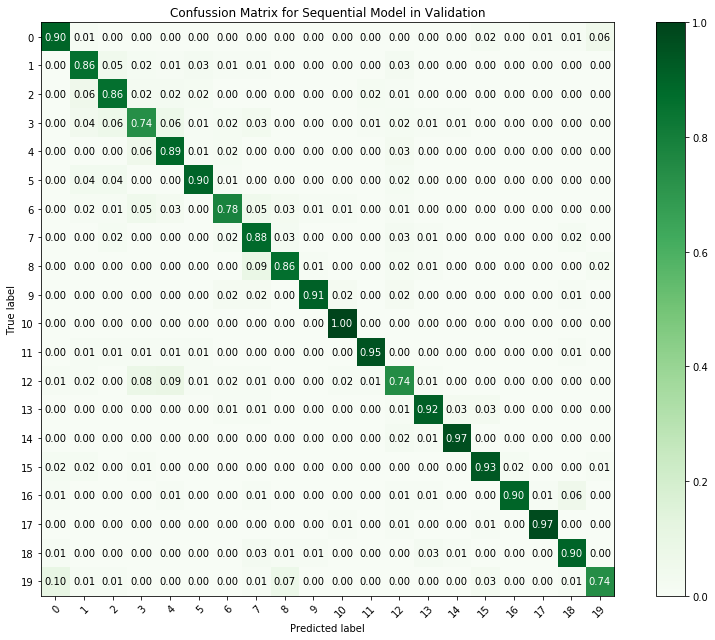

```python
plot_confusion_matrix(y_true = encoder.inverse_transform(y_val), y_pred = modelseq.predict_classes(Xval), classes=[str(cl) for cl in np.unique(twenty_train.target)], title='Confussion Matrix for Sequential Model in Validation')
```

```python
type(conv_model.predict(Xval))
```

```
numpy.ndarray
```

```python
predicted_conv = np.array([np.argmax(arr) for arr in conv_model.predict(Xval)])
```

```
Normalized confusion matrix
[[0.83809524 0.         0.         0.         0.         0.00952381
  0.         0.         0.         0.         0.         0.
  0.         0.00952381 0.         0.02857143 0.00952381 0.01904762
  0.         0.08571429]
 [0.         0.86486486 0.05405405 0.02702703 0.         0.02702703
  0.00900901 0.         0.         0.         0.         0.
  0.00900901 0.         0.00900901 0.         0.         0.
  0.         0.        ]
 [0.         0.05511811 0.85826772 0.06299213 0.00787402 0.00787402
  0.         0.         0.         0.         0.         0.
  0.00787402 0.         0.         0.         0.         0.
  0.         0.        ]
 [0.         0.03174603 0.04761905 0.72222222 0.06349206 0.
  0.04761905 0.01587302 0.         0.         0.         0.
  0.07142857 0.         0.         0.         0.         0.
  0.         0.        ]
 [0.         0.00943396 0.         0.06603774 0.83018868 0.01886792
  0.02830189 0.         0.00943396 0.         0.         0.
  0.03773585 0.         0.         0.         0.         0.
  0.         0.        ]
 [0.         0.09090909 0.04545455 0.         0.00909091 0.81818182
  0.00909091 0.         0.         0.         0.         0.00909091
  0.00909091 0.         0.00909091 0.         0.         0.
  0.         0.        ]
 [0.         0.         0.015625   0.0546875  0.015625   0.
  0.78125    0.046875   0.03125    0.0234375  0.0078125  0.
  0.015625   0.0078125  0.         0.         0.         0.
  0.         0.        ]
 [0.00909091 0.         0.00909091 0.         0.         0.
  0.01818182 0.91818182 0.00909091 0.         0.         0.
  0.02727273 0.00909091 0.         0.         0.         0.
  0.         0.        ]
 [0.         0.         0.         0.         0.         0.
  0.00813008 0.07317073 0.8699187  0.00813008 0.01626016 0.
  0.         0.01626016 0.00813008 0.         0.         0.
  0.         0.        ]
 [0.         0.         0.01       0.         0.         0.
  0.01       0.         0.         0.9        0.03       0.
  0.02       0.         0.         0.02       0.         0.
```

[output cut: 26 more lines]

```
  0.         0.         0.         0.         0.         0.
  0.008      0.         0.008      0.         0.92       0.008
  0.032      0.016     ]
 [0.         0.         0.00854701 0.         0.         0.
  0.         0.00854701 0.         0.         0.         0.
  0.         0.         0.         0.         0.         0.98290598
  0.         0.        ]
 [0.         0.         0.         0.         0.         0.
  0.         0.03797468 0.02531646 0.         0.01265823 0.
  0.         0.02531646 0.         0.         0.         0.01265823
  0.88607595 0.        ]
 [0.07246377 0.         0.         0.         0.         0.
  0.         0.         0.         0.         0.         0.
  0.01449275 0.01449275 0.         0.02898551 0.         0.
  0.01449275 0.85507246]]
```

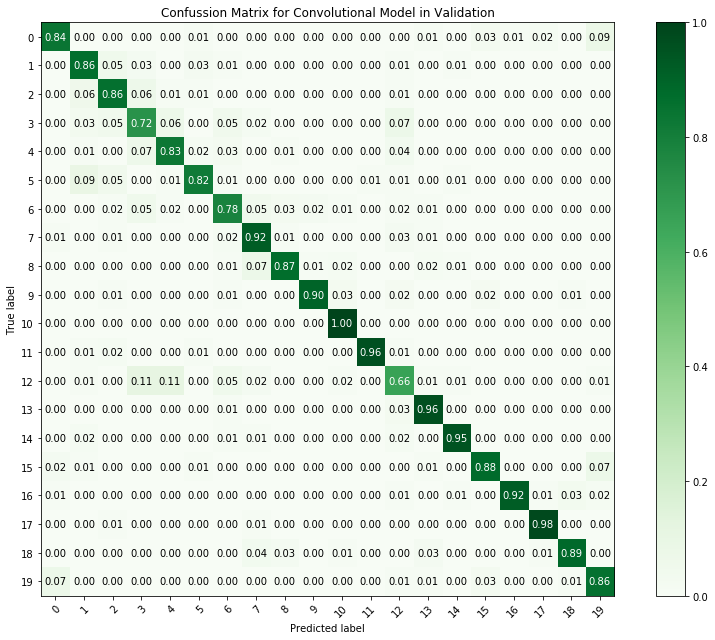

```python
plot_confusion_matrix(y_true = encoder.inverse_transform(y_val), y_pred = predicted_conv, classes=[str(cl) for cl in np.unique(twenty_train.target)], title='Confussion Matrix for Convolutional Model in Validation')
```

```python
model.predict(X_vl)
```

```
array([[1.2772962e-06, 2.7363581e-05, 2.4803219e-06, ..., 2.2802156e-07,
        5.2779092e-07, 5.8332671e-07],
       [1.5136521e-05, 9.9981028e-01, 9.6821086e-06, ..., 1.6882005e-08,
        8.8179135e-08, 9.7407747e-07],
       [7.0268773e-03, 7.4256059e-06, 7.3765549e-09, ..., 2.9232745e-06,
        2.5389807e-06, 4.0105982e-03],
       ...,
       [6.3087066e-07, 1.7487172e-06, 1.4155629e-06, ..., 2.6379081e-07,
        2.9755706e-06, 4.0838722e-07],
       [1.7617994e-08, 4.7646587e-08, 1.5441543e-07, ..., 6.5249219e-09,
        4.8329298e-08, 5.4005977e-09],
       [3.7041126e-08, 3.7931326e-08, 1.0208863e-08, ..., 1.6543177e-08,
        8.8794032e-08, 4.6229315e-10]], dtype=float32)
```

```
Normalized confusion matrix
[[0.95238095 0.         0.         0.         0.         0.
  0.         0.         0.         0.         0.         0.
  0.         0.00952381 0.         0.01904762 0.         0.
  0.00952381 0.00952381]
 [0.         0.89189189 0.02702703 0.02702703 0.00900901 0.03603604
  0.00900901 0.         0.         0.         0.         0.
  0.         0.         0.         0.         0.         0.
  0.         0.        ]
 [0.         0.02362205 0.8976378  0.04724409 0.00787402 0.02362205
  0.         0.         0.         0.         0.         0.
  0.         0.         0.         0.         0.         0.
  0.         0.        ]
 [0.         0.01587302 0.03174603 0.85714286 0.00793651 0.
  0.02380952 0.00793651 0.00793651 0.         0.         0.00793651
  0.03174603 0.         0.         0.         0.         0.
  0.         0.00793651]
 [0.         0.         0.00943396 0.01886792 0.91509434 0.
  0.00943396 0.00943396 0.         0.         0.         0.
  0.02830189 0.00943396 0.         0.         0.         0.
  0.         0.        ]
 [0.         0.02727273 0.03636364 0.00909091 0.         0.9
  0.00909091 0.         0.         0.         0.         0.
  0.01818182 0.         0.         0.         0.         0.
  0.         0.        ]
 [0.         0.0078125  0.0078125  0.03125    0.015625   0.
  0.8203125  0.0625     0.015625   0.         0.0078125  0.
  0.0234375  0.         0.0078125  0.         0.         0.
  0.         0.        ]
 [0.         0.         0.         0.         0.         0.
  0.01818182 0.93636364 0.00909091 0.00909091 0.         0.
  0.00909091 0.         0.         0.         0.01818182 0.
  0.         0.        ]
 [0.         0.         0.         0.         0.00813008 0.
  0.         0.02439024 0.96747967 0.         0.         0.
  0.         0.         0.         0.         0.         0.
  0.         0.        ]
 [0.         0.02       0.         0.         0.         0.
  0.01       0.         0.         0.96       0.         0.
  0.         0.01       0.         0.         0.         0.
```

[output cut: 26 more lines]

```
  0.         0.016      0.         0.         0.         0.
  0.008      0.         0.         0.         0.944      0.
  0.032      0.        ]
 [0.         0.         0.         0.         0.         0.
  0.         0.         0.         0.01709402 0.         0.
  0.         0.         0.         0.         0.         0.97435897
  0.00854701 0.        ]
 [0.         0.         0.01265823 0.         0.         0.
  0.01265823 0.         0.         0.         0.         0.
  0.         0.         0.         0.         0.         0.
  0.97468354 0.        ]
 [0.05797101 0.         0.         0.         0.         0.
  0.         0.01449275 0.01449275 0.01449275 0.         0.
  0.         0.         0.         0.02898551 0.         0.
  0.         0.86956522]]
```

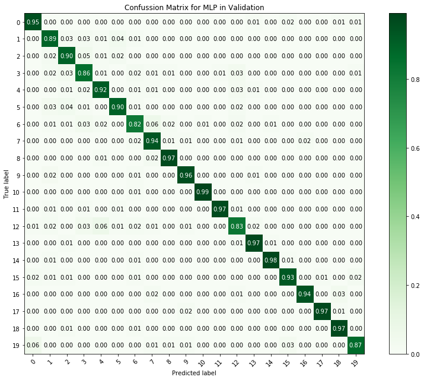

```python
plot_confusion_matrix(y_true = encoder.inverse_transform(y_val), y_pred = model.predict_classes(X_vl), classes=[str(cl) for cl in np.unique(twenty_train.target)], title='Confussion Matrix for MLP in Validation')
```

# Otros Modelos

## SVC (Support Vector Classifier)

```python
sklearn.__version__

from skopt.space import Real, Categorical, Integer
```

Debido a que la versión de sklearn 0.21 no permite el uso de BayesSearchCV, vamos a utilizar la versión de sklearn 0.20.3

```python
from sklearn.svm import LinearSVC

text_clf_svm = Pipeline([('vect', CountVectorizer(max_df=0.5, ngram_range=(1,2))),
                      ('tfidf', TfidfTransformer()),
#                      ('clf-svm', LinearSVC())])
                      ('clf-svm', SGDClassifier(loss='hinge', penalty='elasticnet', alpha=1e-5, random_state=42)), ])
```

```python
#_ = text_clf_svm.fit(text_trn,y_train)
```

```python
#text_clf_svm.score(text_val, y_val)
```

```python
parameters = {'vect__ngram_range': Categorical([(1, 1), (1, 2)]),
              'vect__max_df': Real(0.3, 1.0, prior='log-uniform'),
              'tfidf__use_idf': Categorical([True, False]),
              'clf-svm__alpha': Real(1e-6, 1e-2, prior='log-uniform'),
             'clf-svm__penalty': Categorical(['l2', 'elasticnet'])}
```

```python
gridse = BayesSearchCV(estimator=text_clf_svm, search_spaces=parameters, n_jobs=2, cv=3, random_state=69, n_iter = 15, verbose=2, scoring='accuracy')
```

```python
gridse.fit(text_train, y_train)
```

```
Fitting 3 folds for each of 1 candidates, totalling 3 fits
```

```
[Parallel(n_jobs=2)]: Using backend LokyBackend with 2 concurrent workers.
[Parallel(n_jobs=2)]: Done   3 out of   3 | elapsed:   35.9s finished
[Parallel(n_jobs=2)]: Using backend LokyBackend with 2 concurrent workers.
```

```
Fitting 3 folds for each of 1 candidates, totalling 3 fits
```

```
Fitting 3 folds for each of 1 candidates, totalling 3 fits
```

```
[Parallel(n_jobs=2)]: Done   3 out of   3 | elapsed:   38.3s finished
[Parallel(n_jobs=2)]: Using backend LokyBackend with 2 concurrent workers.
```

```
Fitting 3 folds for each of 1 candidates, totalling 3 fits
```

```
[Parallel(n_jobs=2)]: Done   3 out of   3 | elapsed:    7.2s finished
[Parallel(n_jobs=2)]: Using backend LokyBackend with 2 concurrent workers.
```

```
Fitting 3 folds for each of 1 candidates, totalling 3 fits
```

```
[Parallel(n_jobs=2)]: Done   3 out of   3 | elapsed:    9.9s finished
[Parallel(n_jobs=2)]: Using backend LokyBackend with 2 concurrent workers.
```

```
Fitting 3 folds for each of 1 candidates, totalling 3 fits
```

```
[Parallel(n_jobs=2)]: Done   3 out of   3 | elapsed:   37.6s finished
[Parallel(n_jobs=2)]: Using backend LokyBackend with 2 concurrent workers.
```

```
Fitting 3 folds for each of 1 candidates, totalling 3 fits
```

```
[Parallel(n_jobs=2)]: Done   3 out of   3 | elapsed:   31.6s finished
[Parallel(n_jobs=2)]: Using backend LokyBackend with 2 concurrent workers.
```

```
Fitting 3 folds for each of 1 candidates, totalling 3 fits
```

```
[Parallel(n_jobs=2)]: Done   3 out of   3 | elapsed:   37.3s finished
[Parallel(n_jobs=2)]: Using backend LokyBackend with 2 concurrent workers.
```

```
Fitting 3 folds for each of 1 candidates, totalling 3 fits
```

```
[Parallel(n_jobs=2)]: Done   3 out of   3 | elapsed:    7.2s finished
```

```
Fitting 3 folds for each of 1 candidates, totalling 3 fits
```

```
[Parallel(n_jobs=2)]: Using backend LokyBackend with 2 concurrent workers.
[Parallel(n_jobs=2)]: Done   3 out of   3 | elapsed:    8.5s finished
```

```
Fitting 3 folds for each of 1 candidates, totalling 3 fits
```

```
[Parallel(n_jobs=2)]: Using backend LokyBackend with 2 concurrent workers.
[Parallel(n_jobs=2)]: Done   3 out of   3 | elapsed:   30.4s finished
```

```
Fitting 3 folds for each of 1 candidates, totalling 3 fits
```

```
[Parallel(n_jobs=2)]: Using backend LokyBackend with 2 concurrent workers.
[Parallel(n_jobs=2)]: Done   3 out of   3 | elapsed:    8.1s finished
```

```
Fitting 3 folds for each of 1 candidates, totalling 3 fits
```

```
[Parallel(n_jobs=2)]: Using backend LokyBackend with 2 concurrent workers.
[Parallel(n_jobs=2)]: Done   3 out of   3 | elapsed:   29.8s finished
```

```
Fitting 3 folds for each of 1 candidates, totalling 3 fits
```

```
[Parallel(n_jobs=2)]: Using backend LokyBackend with 2 concurrent workers.
[Parallel(n_jobs=2)]: Done   3 out of   3 | elapsed:   32.0s finished
```

```
Fitting 3 folds for each of 1 candidates, totalling 3 fits
```

```
[Parallel(n_jobs=2)]: Using backend LokyBackend with 2 concurrent workers.
[Parallel(n_jobs=2)]: Done   3 out of   3 | elapsed:   31.3s finished
```

```
BayesSearchCV(cv=3, error_score='raise',
       estimator=Pipeline(memory=None,
     steps=[('vect', CountVectorizer(analyzer='word', binary=False, decode_error='strict',
        dtype=<class 'numpy.int64'>, encoding='utf-8', input='content',
        lowercase=True, max_df=0.5, max_features=None, min_df=1,
        ngram_range=(1, 2), preprocessor=None, stop_words=None,
        strip...dom_state=42, shuffle=True, tol=None,
       validation_fraction=0.1, verbose=0, warm_start=False))]),
       fit_params=None, iid=True, n_iter=15, n_jobs=2, n_points=1,
       optimizer_kwargs=None, pre_dispatch='2*n_jobs', random_state=69,
       refit=True, return_train_score=False, scoring='accuracy',
       search_spaces={'vect__ngram_range': Categorical(categories=((1, 1), (1, 2)), prior=None), 'vect__max_df': Real(low=0.3, high=1.0, prior='log-uniform', transform='identity'), 'tfidf__use_idf': Categorical(categories=(True, False), prior=None), 'clf-svm__alpha': Real(low=1e-06, high=0.01, prior…
       verbose=2)
```

```python
gridse.score(text_valid, encoder.inverse_transform(y_val))
```

```
0.9288555015466196
```

```python
total_X = np.append(text_train, text_valid, axis = 0)
```

```python
y_train.shape
```

```
(9051,)
```

```python
total_Y = np.append(encoder.inverse_transform(y_trn), encoder.inverse_transform(y_val), axis = 0)
```

```python
#_ = gridse.best_estimator_.fit(total_X, total_Y)

#gridse.score(twenty_test.data, twenty_test.target)
```

```
Normalized confusion matrix
[[0.95238095 0.         0.         0.         0.         0.
  0.         0.         0.         0.         0.         0.
  0.         0.         0.         0.02857143 0.         0.
  0.         0.01904762]
 [0.         0.90990991 0.01801802 0.00900901 0.00900901 0.03603604
  0.01801802 0.         0.         0.         0.         0.
  0.         0.         0.         0.         0.         0.
  0.         0.        ]
 [0.         0.03937008 0.91338583 0.01574803 0.00787402 0.01574803
  0.         0.         0.00787402 0.         0.         0.
  0.         0.         0.         0.         0.         0.
  0.         0.        ]
 [0.         0.02380952 0.05555556 0.83333333 0.01587302 0.01587302
  0.02380952 0.00793651 0.         0.         0.         0.
  0.         0.00793651 0.         0.         0.00793651 0.
  0.         0.00793651]
 [0.         0.00943396 0.         0.02830189 0.90566038 0.
  0.01886792 0.         0.         0.         0.         0.
  0.00943396 0.00943396 0.         0.         0.         0.01886792
  0.         0.        ]
 [0.         0.02727273 0.01818182 0.         0.00909091 0.93636364
  0.         0.         0.         0.         0.         0.
  0.         0.         0.00909091 0.         0.         0.
  0.         0.        ]
 [0.0078125  0.0234375  0.0078125  0.015625   0.0234375  0.
  0.84375    0.03125    0.0078125  0.         0.0078125  0.
  0.015625   0.         0.015625   0.         0.         0.
  0.         0.        ]
 [0.         0.         0.         0.         0.         0.
  0.01818182 0.93636364 0.00909091 0.01818182 0.         0.
  0.00909091 0.         0.         0.         0.00909091 0.
  0.         0.        ]
 [0.         0.         0.         0.         0.01626016 0.
  0.         0.00813008 0.97560976 0.         0.         0.
  0.         0.         0.         0.         0.         0.
  0.         0.        ]
 [0.         0.01       0.         0.02       0.         0.
  0.         0.         0.         0.95       0.02       0.
  0.         0.         0.         0.         0.         0.
```

[output cut: 26 more lines]

```
  0.         0.         0.         0.         0.         0.
  0.008      0.         0.008      0.         0.96       0.
  0.016      0.008     ]
 [0.         0.         0.         0.         0.         0.
  0.         0.         0.         0.00854701 0.         0.
  0.         0.         0.         0.00854701 0.         0.98290598
  0.         0.        ]
 [0.         0.         0.01265823 0.         0.         0.
  0.         0.         0.         0.         0.         0.
  0.         0.         0.01265823 0.         0.         0.
  0.97468354 0.        ]
 [0.04347826 0.         0.         0.         0.         0.
  0.         0.01449275 0.01449275 0.         0.         0.
  0.         0.         0.         0.04347826 0.         0.
  0.         0.88405797]]
```

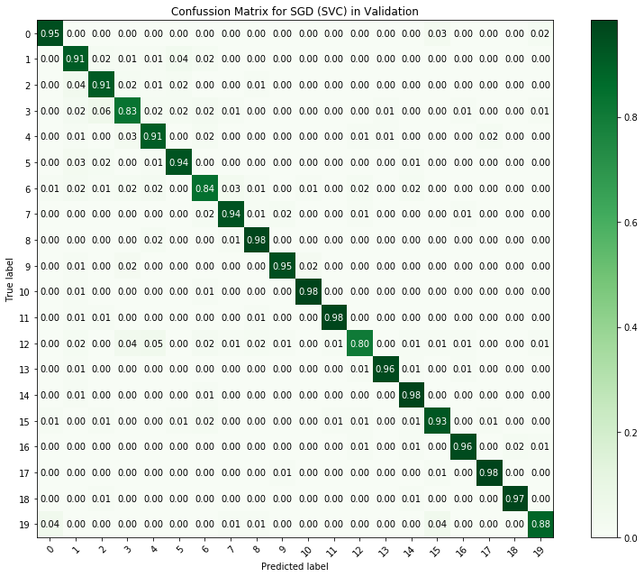

```python
plot_confusion_matrix(y_true = encoder.inverse_transform(y_val), y_pred = gridse.best_estimator_.predict(text_valid), classes=[str(cl) for cl in np.unique(twenty_train.target)], title='Confussion Matrix for SGD (SVC) in Validation')
```

## XGB (eXtreme Gradient Boosting)

Dejamos el código aquí sin ejecutar (comentado) porque esta parte tarda muchísimo, el xgb con tantas columnas es muy costoso entrenarlo y por ese motivo he decidido no incluirlo en la última ejecución, pues tampoco aporta gran cosa a la hora de predecir; de hecho, es bastante pobre prediciendo en comparación con el svm o el "modelseq" que creamos antes.

```python
#xgb = XGBClassifier(max_depth=8, reg_lambda = 0.5, n_estimators=2000, learning_rate=0.01, random_state=42)
```

```python
'''
xgbpipe = Pipeline([('vect', CountVectorizer()),
                   ('tfidf', TfidfTransformer()),
                   ('xgb', XGBClassifier())])

'''
```

```
"\nxgbpipe = Pipeline([('vect', CountVectorizer()),\n                   ('tfidf', TfidfTransformer()),\n                   ('xgb', XGBClassifier())])\n                   \n"
```

```python
'''
parameters_xgb = {'vect__ngram_range': Categorical([(1, 1), (1, 2), (1, 4)]),
              'vect__max_df': Real(0.3, 1.0, prior='log-uniform'),
              'tfidf__use_idf': Categorical([True, False]),
              'xgb__max_depth': Integer(4, 15),
             'xgb__n_estimators': Integer(200, 2000),
             'xgb__learning_rate': Real(0.0001, 0.1, prior='log-uniform'),
             'xgb__reg_lambda': Real(0.00001, 10., prior='log-uniform'),
             'xgb__reg_alpha': Real(0.0000001, 10., prior='log-uniform')}

'''
```

```
"\nparameters_xgb = {'vect__ngram_range': Categorical([(1, 1), (1, 2), (1, 4)]),\n              'vect__max_df': Real(0.3, 1.0, prior='log-uniform'),\n              'tfidf__use_idf': Categorical([True, False]),\n              'xgb__max_depth': Integer(4, 15),\n             'xgb__n_estimators': Intege…
```

```python
#gridse_xgb = BayesSearchCV(estimator=xgbpipe, search_spaces=parameters_xgb, n_jobs=2, cv=3, random_state=69, n_iter = 15, verbose=2, scoring='accuracy')
```

```python
#gridse_xgb.fit(text_train, y_train)
```

```python
#X_trn.shape
```

```python
#gridse_xgb.score(text_valid, encoder.inverse_transform(y_val))
```

```python
#plot_confusion_matrix(y_true = encoder.inverse_transform(y_val), y_pred = gridse_xgb.best_estimator_.predict(text_valid), classes=[str(cl) for cl in np.unique(twenty_train.target)], title='Confussion Matrix for XGB in Validation')
```

## MULTINOMIALNB PIPELINE

```python
from sklearn.ensemble import VotingClassifier

pipe_mnb = Pipeline(steps=[('vect', CountVectorizer(stop_words=stopwords)),
                            ('tfidf', TfidfTransformer()),
                          ('model_mnb', MultinomialNB())])
```

```python
parameters_mnb = {'vect__ngram_range': Categorical([(1, 1), (1, 2), (1, 4)]),
              'vect__min_df': Integer(2, 10),
              'vect__max_df': Real(0.3, 0.95, prior='log-uniform'),
              'vect__max_features': Integer(10000, 20000),
              'tfidf__use_idf': Categorical([True, False])}

gridse_mnb =  BayesSearchCV(estimator=pipe_mnb,search_spaces=parameters_mnb ,scoring='accuracy', n_jobs=2, cv=3, verbose=2, n_iter = 20, random_state=42)
```

```python
gridse_mnb.fit(text_trn, y_train)
```

```
Fitting 3 folds for each of 1 candidates, totalling 3 fits
```

```
[Parallel(n_jobs=2)]: Using backend LokyBackend with 2 concurrent workers.
[Parallel(n_jobs=2)]: Done   3 out of   3 | elapsed:  1.0min finished
[Parallel(n_jobs=2)]: Using backend LokyBackend with 2 concurrent workers.
```

```
Fitting 3 folds for each of 1 candidates, totalling 3 fits
```

```
[Parallel(n_jobs=2)]: Done   3 out of   3 | elapsed:  1.0min finished
[Parallel(n_jobs=2)]: Using backend LokyBackend with 2 concurrent workers.
```

```
Fitting 3 folds for each of 1 candidates, totalling 3 fits
```

```
[Parallel(n_jobs=2)]: Done   3 out of   3 | elapsed:    4.9s finished
[Parallel(n_jobs=2)]: Using backend LokyBackend with 2 concurrent workers.
```

```
Fitting 3 folds for each of 1 candidates, totalling 3 fits
```

```
[Parallel(n_jobs=2)]: Done   3 out of   3 | elapsed:   18.7s finished
[Parallel(n_jobs=2)]: Using backend LokyBackend with 2 concurrent workers.
```

```
Fitting 3 folds for each of 1 candidates, totalling 3 fits
```

```
[Parallel(n_jobs=2)]: Done   3 out of   3 | elapsed:  1.0min finished
[Parallel(n_jobs=2)]: Using backend LokyBackend with 2 concurrent workers.
```

```
Fitting 3 folds for each of 1 candidates, totalling 3 fits
```

```
[Parallel(n_jobs=2)]: Done   3 out of   3 | elapsed:  1.0min finished
[Parallel(n_jobs=2)]: Using backend LokyBackend with 2 concurrent workers.
```

```
Fitting 3 folds for each of 1 candidates, totalling 3 fits
```

```
[Parallel(n_jobs=2)]: Done   3 out of   3 | elapsed:   19.1s finished
[Parallel(n_jobs=2)]: Using backend LokyBackend with 2 concurrent workers.
```

```
Fitting 3 folds for each of 1 candidates, totalling 3 fits
```

```
[Parallel(n_jobs=2)]: Done   3 out of   3 | elapsed:    5.1s finished
[Parallel(n_jobs=2)]: Using backend LokyBackend with 2 concurrent workers.
```

```
Fitting 3 folds for each of 1 candidates, totalling 3 fits
```

```
[Parallel(n_jobs=2)]: Done   3 out of   3 | elapsed:   18.7s finished
```

```
Fitting 3 folds for each of 1 candidates, totalling 3 fits
```

```
[Parallel(n_jobs=2)]: Using backend LokyBackend with 2 concurrent workers.
[Parallel(n_jobs=2)]: Done   3 out of   3 | elapsed:   18.8s finished
```

```
Fitting 3 folds for each of 1 candidates, totalling 3 fits
```

```
[Parallel(n_jobs=2)]: Using backend LokyBackend with 2 concurrent workers.
[Parallel(n_jobs=2)]: Done   3 out of   3 | elapsed:    5.3s finished
```

```
Fitting 3 folds for each of 1 candidates, totalling 3 fits
```

```
[Parallel(n_jobs=2)]: Using backend LokyBackend with 2 concurrent workers.
[Parallel(n_jobs=2)]: Done   3 out of   3 | elapsed:    4.9s finished
```

```
Fitting 3 folds for each of 1 candidates, totalling 3 fits
```

```
[Parallel(n_jobs=2)]: Using backend LokyBackend with 2 concurrent workers.
[Parallel(n_jobs=2)]: Done   3 out of   3 | elapsed:    4.6s finished
```

```
Fitting 3 folds for each of 1 candidates, totalling 3 fits
```

```
[Parallel(n_jobs=2)]: Using backend LokyBackend with 2 concurrent workers.
[Parallel(n_jobs=2)]: Done   3 out of   3 | elapsed:    4.6s finished
```

```
Fitting 3 folds for each of 1 candidates, totalling 3 fits
```

```
[Parallel(n_jobs=2)]: Using backend LokyBackend with 2 concurrent workers.
[Parallel(n_jobs=2)]: Done   3 out of   3 | elapsed:    4.7s finished
```

```
Fitting 3 folds for each of 1 candidates, totalling 3 fits
```

```
[Parallel(n_jobs=2)]: Using backend LokyBackend with 2 concurrent workers.
[Parallel(n_jobs=2)]: Done   3 out of   3 | elapsed:   18.7s finished
```

```
Fitting 3 folds for each of 1 candidates, totalling 3 fits
```

```
[Parallel(n_jobs=2)]: Using backend LokyBackend with 2 concurrent workers.
[Parallel(n_jobs=2)]: Done   3 out of   3 | elapsed:    4.7s finished
```

```
Fitting 3 folds for each of 1 candidates, totalling 3 fits
```

```
[Parallel(n_jobs=2)]: Using backend LokyBackend with 2 concurrent workers.
[Parallel(n_jobs=2)]: Done   3 out of   3 | elapsed:    4.8s finished
```

```
Fitting 3 folds for each of 1 candidates, totalling 3 fits
```

```
[Parallel(n_jobs=2)]: Using backend LokyBackend with 2 concurrent workers.
[Parallel(n_jobs=2)]: Done   3 out of   3 | elapsed:    4.7s finished
```

```
Fitting 3 folds for each of 1 candidates, totalling 3 fits
```

```
[Parallel(n_jobs=2)]: Using backend LokyBackend with 2 concurrent workers.
[Parallel(n_jobs=2)]: Done   3 out of   3 | elapsed:    4.7s finished
```

```
BayesSearchCV(cv=3, error_score='raise',
       estimator=Pipeline(memory=None,
     steps=[('vect', CountVectorizer(analyzer='word', binary=False, decode_error='strict',
        dtype=<class 'numpy.int64'>, encoding='utf-8', input='content',
        lowercase=True, max_df=1.0, max_features=None, min_df=1,
        ngram_range=(1, 1), preprocessor=None,
        stop_words=['i', 'me',...tf=False, use_idf=True)), ('model_mnb', MultinomialNB(alpha=1.0, class_prior=None, fit_prior=True))]),
       fit_params=None, iid=True, n_iter=20, n_jobs=2, n_points=1,
       optimizer_kwargs=None, pre_dispatch='2*n_jobs', random_state=42,
       refit=True, return_train_score=False, scoring='accuracy',
       search_spaces={'vect__ngram_range': Categorical(categories=((1, 1), (1, 2), (1, 4)), prior=None), 'vect__min_df': Integer(low=2, high=10), 'vect__max_df': Real(low=0.3, high=0.95, prior='log-uniform', transform='identity'), 'vect__max_features': Integer(low=10000, high=20000), 'tfidf__use_idf…
       verbose=2)
```

```python
gridse_mnb.score(text_val, encoder.inverse_transform(y_val))
```

```
0.8886433937251436
```

```python
from sklearn.neural_network import MLPClassifier
```

## VOTINGCLASSIFIER(SGD - SVC + MNB)

Queríamos haber metido también el modelo hecho con keras de MLP, pero no nos deja Google por memoria, se me desconecta el entorno constantemente cuando lo ejecuto. Como necesitaríamos que fueran al menos 3 para que la votación tuviera sentido, lo dejamos entero comentado.

```python
'''voting_class = VotingClassifier(estimators= [
         ('svm', SGDClassifier(alpha=8.254279797686614e-05,
         l1_ratio=0.15, learning_rate='optimal', loss='hinge',
         n_jobs=-1, penalty='l2',
         power_t=0.5, random_state=42, shuffle=True,
         validation_fraction=0.1, verbose=0, warm_start=True)),  ('mnb', MultinomialNB())],
         voting='hard', weights=[1.5, 1])
'''
#('mlp', MLPClassifier(hidden_layer_sizes=(200, ), early_stopping=True, learning_rate='adaptive', alpha=1.)),
```

```
"voting_class = VotingClassifier(estimators= [\n         ('svm', SGDClassifier(alpha=8.254279797686614e-05,\n         l1_ratio=0.15, learning_rate='optimal', loss='hinge',\n         n_jobs=-1, penalty='l2',\n         power_t=0.5, random_state=42, shuffle=True,\n         validation_fraction=0.1, verb…
```

```python
'''
pipe_voting = Pipeline(steps = [('vect', CountVectorizer(analyzer='word', binary=False, decode_error='strict',
                                                        encoding='utf-8', input='content',
                                                        lowercase=True, max_df=0.5, max_features=None, min_df=1,
                                                        ngram_range=(1, 2), preprocessor=None, stop_words=None,
                                                        strip_accents=None, token_pattern='(?u)\\b\\w\\w+\\b',
                                                        tokenizer=None, vocabulary=None)),
                               ('tfidf', TfidfTransformer(norm='l2', smooth_idf=True, sublinear_tf=False, use_idf=True)),
                               ('model', voting_class)])

'''
```

```
"\npipe_voting = Pipeline(steps = [('vect', CountVectorizer(analyzer='word', binary=False, decode_error='strict',\n                                                        encoding='utf-8', input='content',\n                                                        lowercase=True, max_df=0.5, max_featu…
```

```python
#pipe_voting.fit(total_X, total_Y)
```

```python
#pipe_voting.score(twenty_test.data, twenty_test.target)
```

## 04 Evaluate valid data

```python
# Confussion matrix

# Evalaute valid data
#pred_val = score_function(text_val, grid_svc, stopwords, punctuations)

#Calculate accuracy with sklearn
#print('Accuracy valid: ', accuracy_score(y_val, pred_val))
#pd.DataFrame(confusion_matrix(y_val, pred_val))


def definitive_score(test, model):

  return model.predict(test.data)
```

## 05 Evaluate test data

- Don't edit after this!!!
- Execute only ONCE whit the optimal model selected based on the validation accuracy metric calculated over multiple experiments.

```python
twenty_test = fetch_20newsgroups(subset='test')#  , remove=('headers', 'footers', 'quotes'))
```

```python
X_test, y_test = get_test(twenty_test, stopwords=stopwords, punctuations=string.punctuation, maxwords=20000, seqlen=1000, logging=True)
```

```python
X_test_matrix, y_test = get_test(twenty_test, stopwords=stopwords, punctuations=string.punctuation, maxwords = 20000, seqlen =1000, logging=True, mode='matrix', sparse=True)
```

```python
conv_model.evaluate(X_test, y_test)
```

```
[0.6976291590780257, 0.8159851301431783]
```

```python
modelseq.evaluate(X_test, y_test)
```

```
[0.7736152869491456, 0.8133297928836962]
```

```python
#X_test_matrix
```

```python
model.evaluate(X_test_matrix, y_test)
```

```
[0.5768781608555207, 0.8430695698037151]
```

```python
gridse.best_estimator_.fit(total_X, total_Y)
```

```
Pipeline(memory=None,
     steps=[('vect', CountVectorizer(analyzer='word', binary=False, decode_error='strict',
        dtype=<class 'numpy.int64'>, encoding='utf-8', input='content',
        lowercase=True, max_df=0.3, max_features=None, min_df=1,
        ngram_range=(1, 2), preprocessor=None, stop_words=None,
        strip...dom_state=42, shuffle=True, tol=None,
       validation_fraction=0.1, verbose=0, warm_start=False))])
```

```python
gridse.score(twenty_test.data, twenty_test.target)
```

```
0.8583377588953797
```

```python
#X_test, y_test = get_test(twenty_test, stopwords=stopwords, punctuations=string.punctuation, maxwords=20000, seqlen=1000, logging=True)
```

```python
print('Accuracy test: {} '.format(sklearn.metrics.accuracy_score(twenty_test.target, definitive_score(twenty_test, gridse))))
```

```
Accuracy test: 0.8583377588953797
```

```python
'''
# Test Accuracy

twenty_test = fetch_20newsgroups(subset='test', remove=('headers', 'footers', 'quotes'))

predicted = score_function(twenty_test.data, model=modelseq, stopwords=stopwords, punctuations=string.punctuation, seqlen=300, logging=True)

print('Accuracy test: ', accuracy_score(twenty_test.target, predicted))

'''
```

```python
#sklearn.metrics.accuracy_score(twenty_test.target, text_clf_svm.predict(twenty_test.data))
```